# Part II - Gender gap in upbringing of school children

## based on PISA 2022 Database: *School students questionnaire conducated in more than 70 countries* by Madina Madeyeva

## Investigation Overview

> The goal of this report is to highlight on gender biases in upbringing of children, which are not only observed on average of >400 000 kids (in more than 73 countries).

> Boys in the observed dataset dedicate more time on doing Sports, while girls on school homework.

> Work for pay has a similar trend of boys spending more time compared to girls on average for this activity.

## Dataset Overview

> The analysis is based on PISA 2022 Database, which represents questionnaire results of school children conducted in more than 70 countries. The data can be found and downloaded via the following website: https://www.oecd.org/en/data/datasets/pisa-2022-database.html

## Visualization 1. Number of days per week spend on Sports per Gender

> Number of female school children, who do not participate in any Sports (after school) is 1.8 times higher than the number of male school children.

> At the same time, number of boys, who spend 5 or more days on doing sports, is exactly 1.8 times higher than girls.

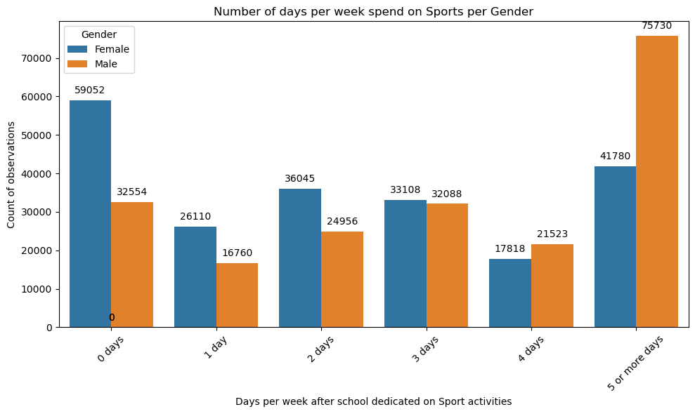

## Visualization 2. Number of days per week spend on Work for pay per Gender

> Boys spend more days per week on Work for pay activities in all the categories, number of girls is high only in the category of 0 days per week spend on Work for pay activities.

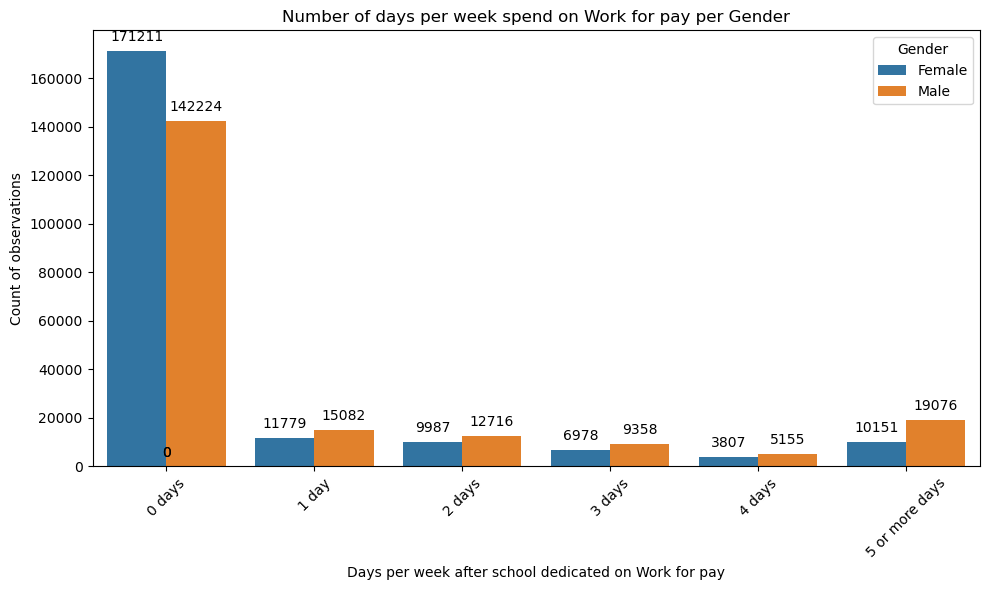

## Visualization 3. Number of days per week spend to perform school homework per Gender

> More proportion of boys spend less than 5 days to perform school homework than girls.

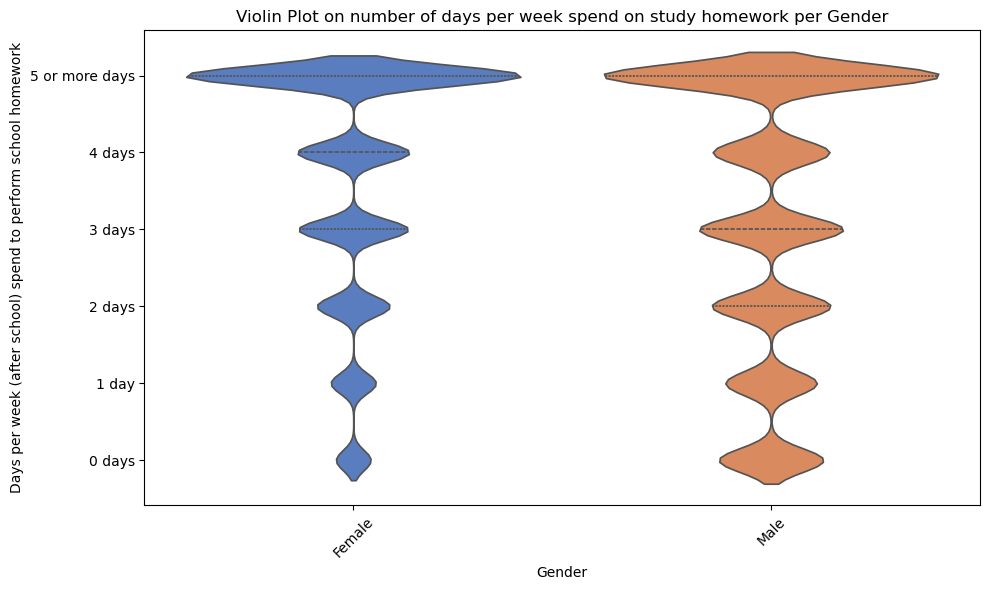